# 07 Resumen ETS

Author

Eddie Aguilar

```r
library(easypackages)
libraries("tidyverse","fpp3", "patchwork","plotly")
```

Los métodos de suavización exponencial son promedios ponderados de los datos anteriores, donde sus pesos caen exponencialmente.

# Suavización exponencial simple

- SES, Simple exponential smoothing.
- Es el más simple.
- Sirve para series sin estacionalidad ni tendencia clara.

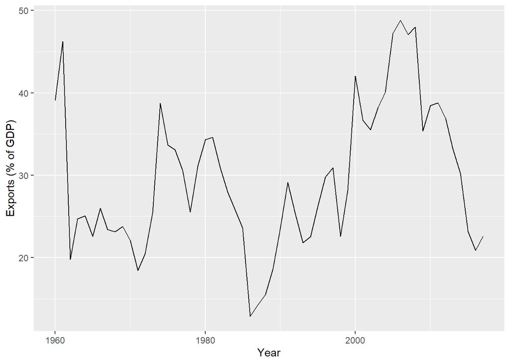

```r
algeria_economy <- global_economy %>%
  filter(Country == "Algeria")
algeria_economy %>%
  autoplot(Exports) +
  ylab("Exports (% of GDP)") + xlab("Year")
```

Para entender las medias ponderadas, veamos los siguientes métodos:

- Snaive agarra el último valor y lo despliega en el horizonte.
- Media saca un promedio de todos los valores y lo despliega en el horizonte.

Entonces tenemos que:

- Snaive es una media ponderada, donde la última observación tiene un peso de 100% (1).
- Media es una media ponderada, donde todos los valores tienen el mismo peso (simplemente media)

Por lo tanto, un punto intermedio es la suavización exponencial simple.

Donde $\alpha$ es el parámetro de suavizazión (de 0 a 1), entre más bajo sea el valor, más memoria tendrá y vice versa, esto debido a que decae de forma exponencial el peso de y en cada momento T. Si tenemos un valor muy grande de $\alpha$ decaerá más rápido.

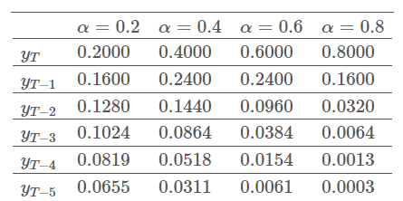

Los pronósticos de suavización exponencial simple toma el mismo valor para todo el horizonte.

Para encontrar el valor de $\alpha$ usamos opt_crit(), puede ser a través del log-likelihood (lik), error medio cuadrático (mse) o el error medio absoluto (mae). El error se puede calcular de forma aditiva (“A”) o de forma multiplicativa (“M”).

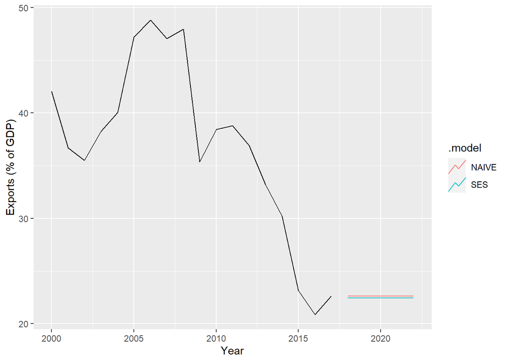

```r
# Estimar los parámetros
fit <- algeria_economy %>%
  model(SES   = ETS(Exports ~ error("A") + trend("N") + season("N"), opt_crit = "mse"),
        NAIVE = NAIVE(Exports))

fc <- fit %>%
  forecast(h = 5)

fc %>%
  autoplot(algeria_economy %>% filter_index("2000"~.), level = NULL) +
  # geom_line(aes(y = .fitted, colour = "Fitted"), data = augment(fit)) +
  ylab("Exports (% of GDP)") + xlab("Year")
```

```r
fit %>%
  select(SES) %>%
  report()
```

```
Series: Exports
Model: ETS(A,N,N)
  Smoothing parameters:
    alpha = 0.839812

  Initial states:
     l[0]
 39.54013

  sigma^2:  35.6301

     AIC     AICc      BIC
446.7154 447.1599 452.8968
```

# Métodos con tendencia

## El modelo de tendencia lineal de Holt

Ya se permite el pronóstico de tendencia. Además de $\alpha$ (término de suavización), tenemos ahora $\beta$ que es el parámetro de suavización de la tendencia. Solo tenemos que agregar el término trend(“A”) al modelo (tendencia aditiva).

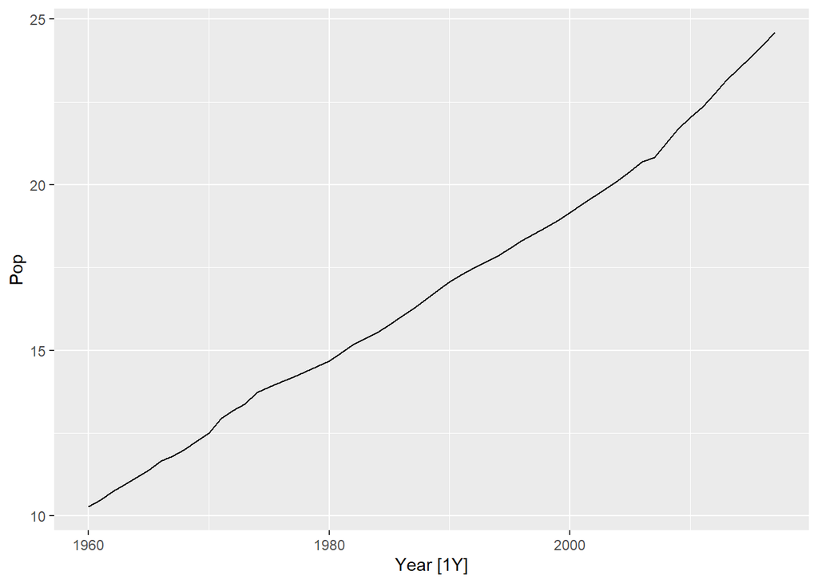

```r
aus_economy <- global_economy %>%
  filter(Code == "AUS") %>%
  mutate(Pop = Population / 1e6)

aus_economy %>%
  autoplot(Pop)
```

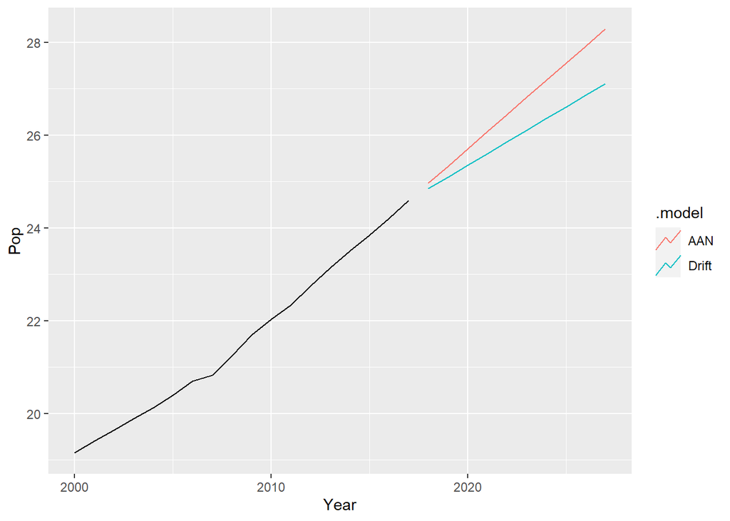

```r
fit <- aus_economy %>%
  model(AAN   = ETS(Pop ~ error("A") + trend("A") + season("N")),
        Drift = RW(Pop ~ drift()))

fc <- fit %>% forecast(h = 10)

fc %>%
  autoplot(aus_economy %>% filter_index("2000"~.), level = NULL)
```

```r
fit %>%
  glance()
```

```
# A tibble: 2 × 10
  Country   .model  sigma2 log_lik   AIC  AICc   BIC      MSE    AMSE     MAE
  <fct>     <chr>    <dbl>   <dbl> <dbl> <dbl> <dbl>    <dbl>   <dbl>   <dbl>
1 Australia AAN    0.00413    43.5 -77.0 -75.8 -66.7  0.00385  0.0120  0.0432
2 Australia Drift  0.00601    NA    NA    NA    NA   NA       NA      NA
```

```r
fit %>%
  select(AAN) %>%
  report()
```

```
Series: Pop
Model: ETS(A,A,N)
  Smoothing parameters:
    alpha = 0.9999
    beta  = 0.3266366

  Initial states:
     l[0]      b[0]
 10.05414 0.2224818

  sigma^2:  0.0041

      AIC      AICc       BIC
-76.98569 -75.83184 -66.68347
```

## Métodos de tendencia amortiguada (damped trend)

El valor de $\pih$ suele ser mayor a 0.8 la mayoría dle timepo, ya que el amortiguemiento puede ser muy fuerte para valores más bajos. Comparando los deos métodos:

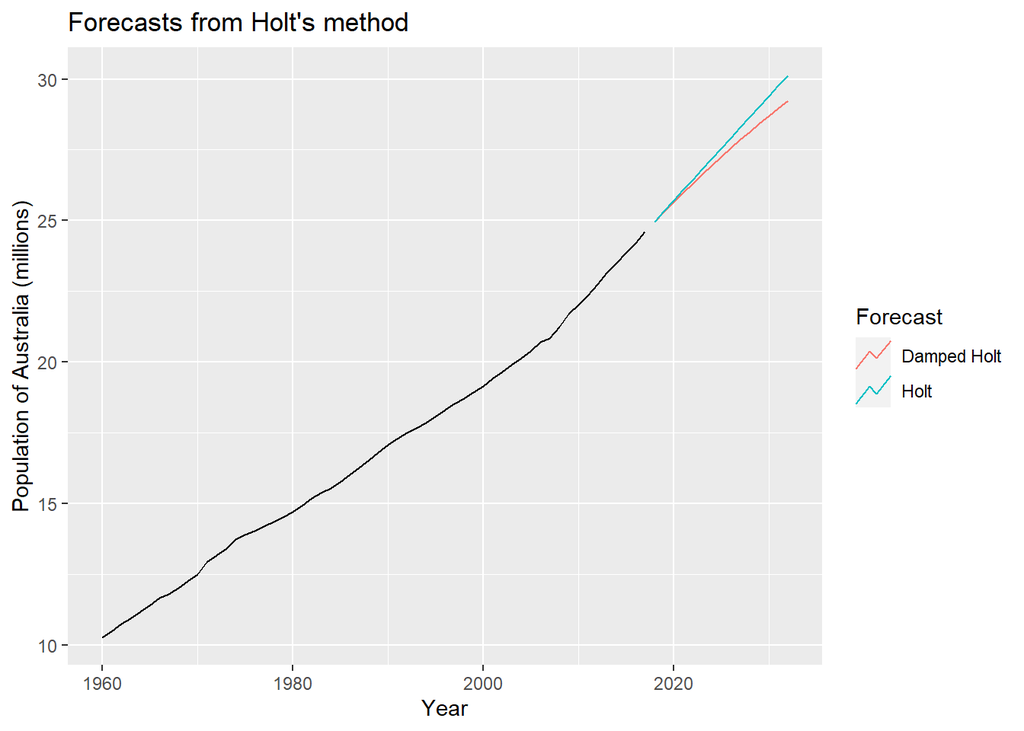

```r
aus_economy %>%
  model(
    `Holt` = ETS(Pop ~ error("A") + trend("A")),
    `Damped Holt` = ETS(Pop ~ error("A") + trend("Ad"))
  ) %>%
  forecast(h = "15 years") %>%
  autoplot(aus_economy, level = NULL) +
  ggtitle("Forecasts from Holt's method") + xlab("Year") +
  ylab("Population of Australia (millions)") +
  guides(colour = guide_legend(title = "Forecast"))
```

```r
aus_economy %>%
  model(
    `Damped Holt` = ETS(Pop ~ error("A") + trend("Ad"))
  ) %>%
  report()
```

```
Series: Pop
Model: ETS(A,Ad,N)
  Smoothing parameters:
    alpha = 0.9986305
    beta  = 0.4271838
    phi   = 0.98

  Initial states:
     l[0]      b[0]
 10.03648 0.2478533

  sigma^2:  0.0045

      AIC      AICc       BIC
-71.01630 -69.36924 -58.65364
```

Con $\pih$ siendo 0.8:

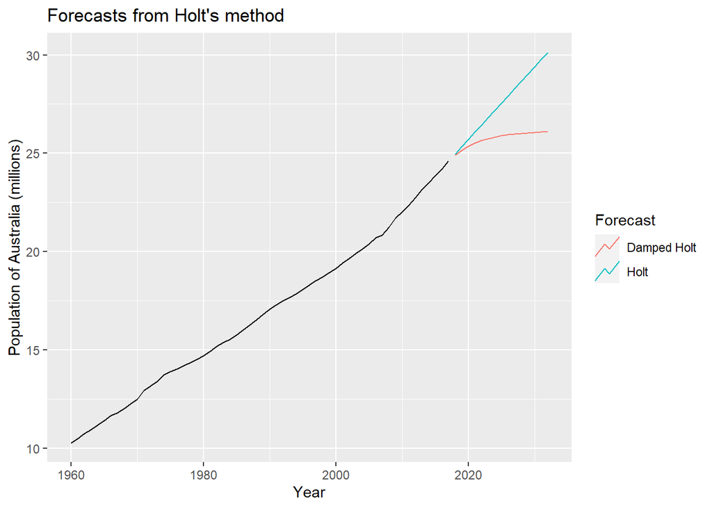

```r
aus_economy %>%
  model(
    `Holt` = ETS(Pop ~ error("A") + trend("A")),
    `Damped Holt` = ETS(Pop ~ error("A") + trend("Ad", phi = 0.8))
  ) %>%
  forecast(h = "15 years") %>%
  autoplot(aus_economy, level = NULL) +
  ggtitle("Forecasts from Holt's method") + xlab("Year") +
  ylab("Population of Australia (millions)") +
  guides(colour = guide_legend(title = "Forecast"))
```

```r
pop_fit <- aus_economy %>%
  model(
    `Damped Holt mse` = ETS(Pop ~ error("A") + trend("Ad"), opt_crit = "mse"),
    `Damped Holt lik` = ETS(Pop ~ error("A") + trend("Ad"), opt_crit = "lik")
  )

pop_fit %>%
  select(`Damped Holt mse`) %>%
  report()
```

```
Series: Pop
Model: ETS(A,Ad,N)
  Smoothing parameters:
    alpha = 0.9983631
    beta  = 0.4271731
    phi   = 0.98

  Initial states:
     l[0]      b[0]
 10.03647 0.2477941

  sigma^2:  0.0045

      AIC      AICc       BIC
-71.01628 -69.36923 -58.65363
```

```r
pop_fit %>%
  select(`Damped Holt lik`) %>%
  report()
```

```
Series: Pop
Model: ETS(A,Ad,N)
  Smoothing parameters:
    alpha = 0.9986305
    beta  = 0.4271838
    phi   = 0.98

  Initial states:
     l[0]      b[0]
 10.03648 0.2478533

  sigma^2:  0.0045

      AIC      AICc       BIC
-71.01630 -69.36924 -58.65364
```

```r
pop_fit %>% tidy()
```

```
# A tibble: 10 × 4
   Country   .model          term  estimate
   <fct>     <chr>           <chr>    <dbl>
 1 Australia Damped Holt mse alpha    0.998
 2 Australia Damped Holt mse beta     0.427
 3 Australia Damped Holt mse phi      0.980
 4 Australia Damped Holt mse l[0]    10.0
 5 Australia Damped Holt mse b[0]     0.248
 6 Australia Damped Holt lik alpha    0.999
 7 Australia Damped Holt lik beta     0.427
 8 Australia Damped Holt lik phi      0.980
 9 Australia Damped Holt lik l[0]    10.0
10 Australia Damped Holt lik b[0]     0.248
```

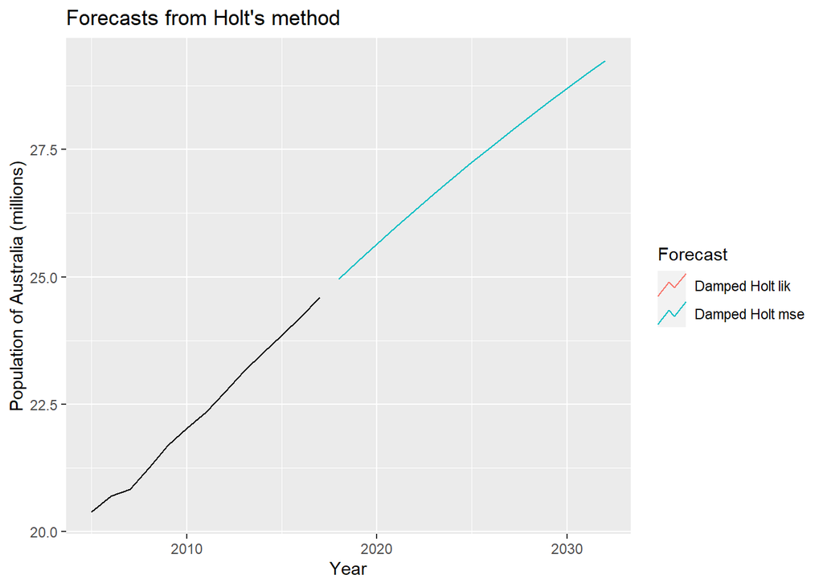

```r
pop_fit %>%
  forecast(h = 15) %>%
  autoplot(aus_economy %>% filter_index("2005"~.), level = NULL) +
  ggtitle("Forecasts from Holt's method") + xlab("Year") +
  ylab("Population of Australia (millions)") +
  guides(colour = guide_legend(title = "Forecast"))
```

Otro ejemplo:

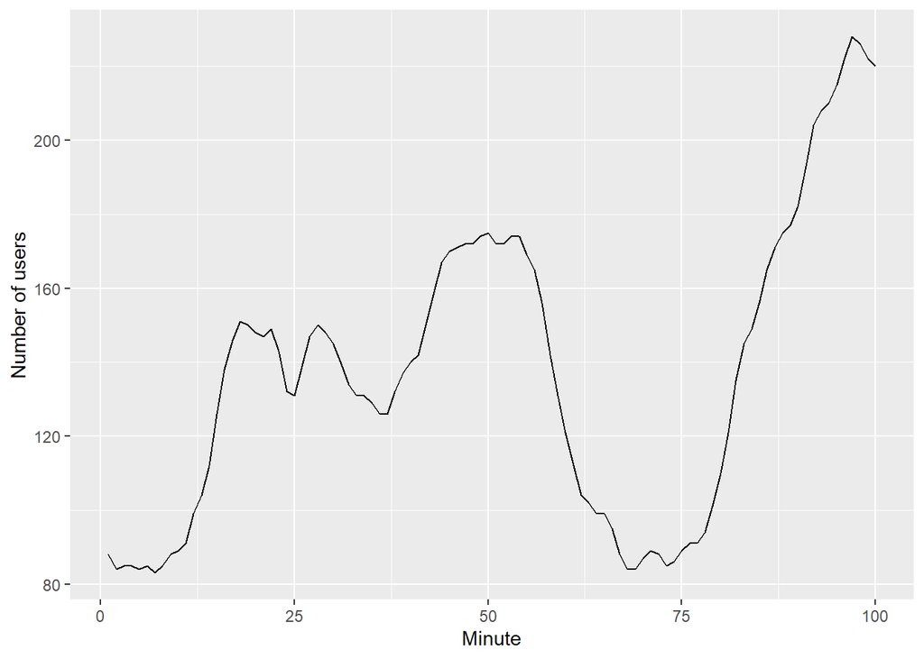

```r
www_usage <- as_tsibble(WWWusage)
www_usage %>% autoplot(value) +
  xlab("Minute") + ylab("Number of users")
```

```r
www_usage %>%
  stretch_tsibble(.init = 10) %>%
  model(
    SES = ETS(value ~ error("A") + trend("N") + season("N")),
    Holt = ETS(value ~ error("A") + trend("A") + season("N")),
    Damped = ETS(value ~ error("A") + trend("Ad") + season("N"))
  ) %>%
  forecast(h = 1) %>%
  accuracy(www_usage)
```

```
# A tibble: 3 × 10
  .model .type     ME  RMSE   MAE   MPE  MAPE  MASE RMSSE  ACF1
  <chr>  <chr>  <dbl> <dbl> <dbl> <dbl> <dbl> <dbl> <dbl> <dbl>
1 Damped Test  0.288   3.69  3.00 0.347  2.26 0.663 0.636 0.336
2 Holt   Test  0.0610  3.87  3.17 0.244  2.38 0.701 0.668 0.296
3 SES    Test  1.46    6.05  4.81 0.904  3.55 1.06  1.04  0.803
```

```r
fit <- www_usage %>%
  model(Damped = ETS(value ~ error("A") + trend("Ad") + season("N")))
# Los parámetros estimados:
tidy(fit)
```

```
# A tibble: 5 × 3
  .model term  estimate
  <chr>  <chr>    <dbl>
1 Damped alpha   1.00
2 Damped beta    0.997
3 Damped phi     0.815
4 Damped l[0]   90.4
5 Damped b[0]   -0.0173
```

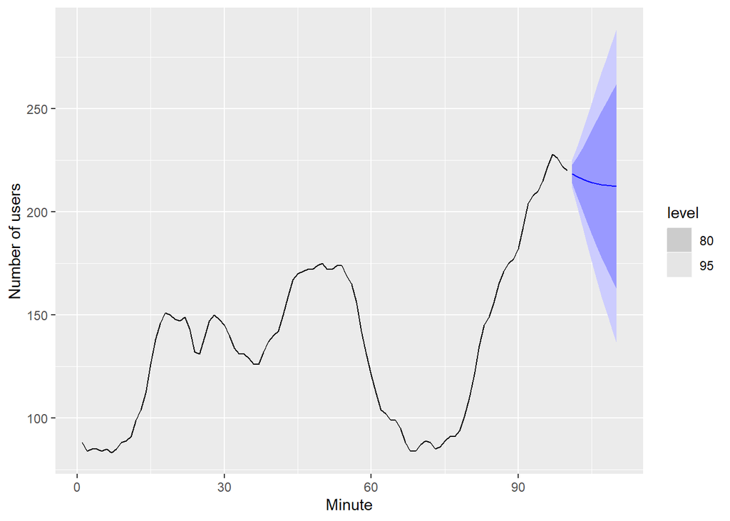

```r
fit %>%
  forecast(h = 10) %>%
  autoplot(www_usage) +
  xlab("Minute") + ylab("Number of users")
```

# Métodos con estacionalidad

## Modelo de Holt-Winters

Se agrega el parámetro estacional $\gamma$. Hay dos variantes de este método: aditivo y multiplicativo.

Aditivo se usa para estacinoalidad constante en el tiempo (season(“A”)), y multiplitcativo para cuando varia (season(“M”)).

```
Plot variable not specified, automatically selected `.vars = Trips`
```

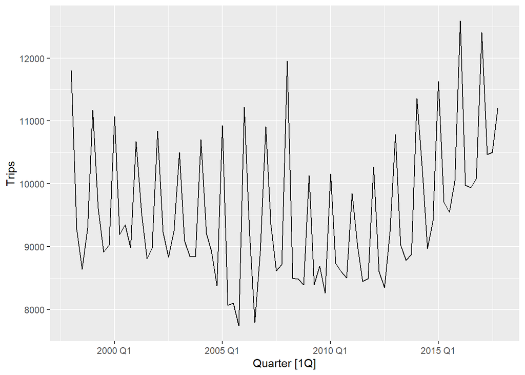

```r
aus_holidays <- tourism %>%
  filter(Purpose == "Holiday") %>%
  summarise(Trips = sum(Trips))

aus_holidays %>%
  autoplot()
```

```r
fit <- aus_holidays %>%
  model(
    additive = ETS(Trips ~ error("A") + trend("A") + season("A")),
    multiplicative = ETS(Trips ~ error("M") + trend("A") + season("M"))
  )

fit %>% tidy()
```

```
# A tibble: 18 × 3
   .model         term     estimate
   <chr>          <chr>       <dbl>
 1 additive       alpha    0.236
 2 additive       beta     0.0298
 3 additive       gamma    0.000100
 4 additive       l[0]  9899.
 5 additive       b[0]   -37.4
 6 additive       s[0]  -538.
 7 additive       s[-1] -684.
 8 additive       s[-2] -290.
 9 additive       s[-3] 1512.
10 multiplicative alpha    0.186
11 multiplicative beta     0.0248
12 multiplicative gamma    0.000100
13 multiplicative l[0]  9853.
14 multiplicative b[0]   -33.4
15 multiplicative s[0]     0.943
16 multiplicative s[-1]    0.926
17 multiplicative s[-2]    0.970
18 multiplicative s[-3]    1.16
```

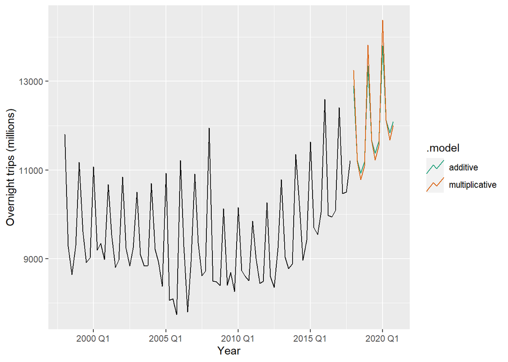

```r
fc <- fit %>% forecast(h = "3 years")

fc %>%
  autoplot(aus_holidays, level = NULL) + xlab("Year") +
  ylab("Overnight trips (millions)") +
  scale_color_brewer(type = "qual", palette = "Dark2")
```

## Modelo de Holt-Winters amortiguado

Se puede amortiguar cualquiera de las dos variantes del modelo Holt-Winters.

Un método que suele ser robusto es el método Holt-Winters con tendencia amortiguada y estacionalidad multiplicativa:

```r
ETS(y ~ error("M") + trend("Ad") + season("M"))
```

```
<ETS model definition>
```

Probando con los datos del tráfico de peatones con estacionalidad semanal y datos diarios:

```r
(sth_cross_ped <- pedestrian %>%
  filter(Sensor == "Southern Cross Station", yearmonth(Date) == yearmonth("2016 July")) %>%
  index_by(Date) %>%
  summarise(Count = sum(Count)))
```

```
# A tsibble: 31 x 2 [1D]
   Date       Count
   <date>     <int>
 1 2016-07-01 17583
 2 2016-07-02  2525
 3 2016-07-03  1733
 4 2016-07-04 17274
 5 2016-07-05 16467
 6 2016-07-06 16773
 7 2016-07-07 16955
 8 2016-07-08 17225
 9 2016-07-09  3211
10 2016-07-10  1751
# … with 21 more rows
```

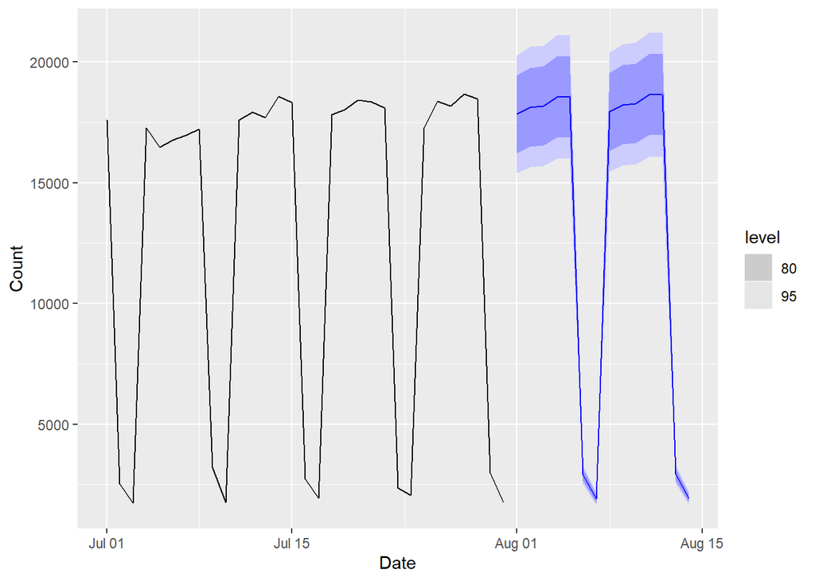

```r
sth_cross_ped %>%
  model(hw = ETS(Count ~ error("M") + trend("Ad") + season("M"))) %>%
  forecast(h = "2 weeks") %>%
  autoplot(sth_cross_ped)
```

## Selección automática del modelo ETS

```r
ets_automatico <- sth_cross_ped %>%
  model(hw = ETS(Count))
ets_automatico %>%
  report()
```

```
Series: Count
Model: ETS(A,N,A)
  Smoothing parameters:
    alpha = 0.6225005
    gamma = 0.0001219715

  Initial states:
     l[0]     s[0]    s[-1]   s[-2]    s[-3]     s[-4]     s[-5]    s[-6]
 13290.13 4755.795 4380.487 4327.99 4132.827 -11530.02 -10608.26 4541.183

  sigma^2:  244037.1

     AIC     AICc      BIC
500.3797 511.3797 514.7195
```

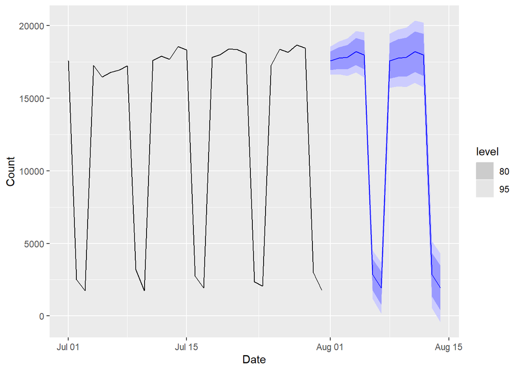

```r
ets_automatico %>%
  forecast(h = "2 weeks") %>%
  autoplot(sth_cross_ped)
```

Comparando:

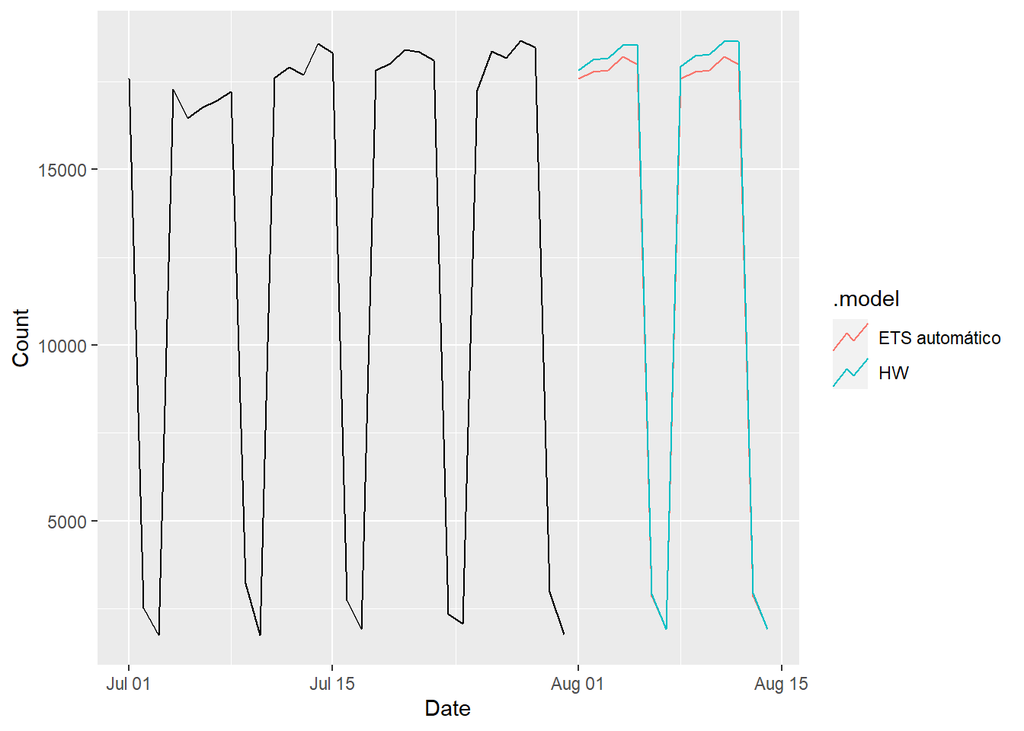

```r
sth_cross_ped %>%
  model(`ETS automático` = ETS(Count),
        `HW`             = ETS(Count ~ error("M") + trend("Ad") + season("M"))
        ) %>%
  forecast(h = "2 weeks") %>%
  autoplot(sth_cross_ped, level = NULL)
```

```r
sth_cross_ped %>%
  model(`ETS automático` = ETS(Count),
        `HW`             = ETS(Count ~ error("M") + trend("Ad") + season("M"))
        ) %>%
  accuracy()
```

```
# A tibble: 2 × 10
  .model         .type        ME  RMSE   MAE    MPE  MAPE  MASE RMSSE   ACF1
  <chr>          <chr>     <dbl> <dbl> <dbl>  <dbl> <dbl> <dbl> <dbl>  <dbl>
1 ETS automático Training   8.55  416.  302. -0.442  5.79 0.609 0.651 0.0193
2 HW             Training 130.    379.  314.  0.292  3.78 0.634 0.593 0.0540
```

# Variedad de métodos de suavización exponencial

Resumen de los métodos de suavización exponencial:

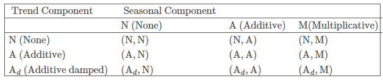

Combinaciones:

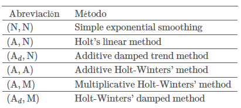

# Comparación con métodos benchmark

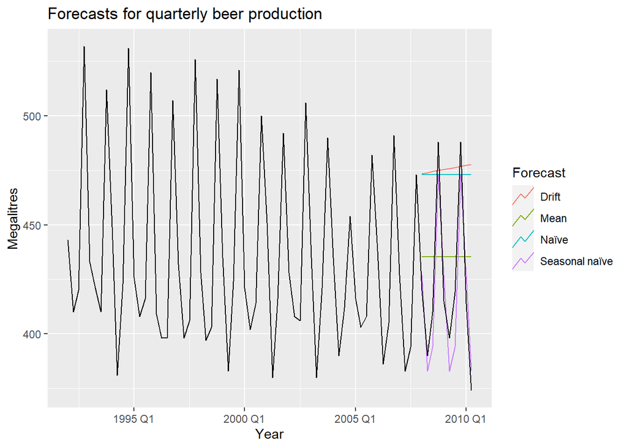

```r
recent_production <- aus_production %>% filter(year(Quarter) >= 1992)
beer_train <- recent_production %>% filter(year(Quarter) <= 2007)

beer_fit <- beer_train %>%
  model(
    Mean = MEAN(Beer),
    `Naïve` = NAIVE(Beer),
    `Seasonal naïve` = SNAIVE(Beer),
    Drift = RW(Beer ~ drift())
  )

beer_fc <- beer_fit %>%
  forecast(h = 10)

beer_fc %>%
  autoplot(filter(aus_production, year(Quarter) >= 1992), level = NULL) +
  xlab("Year") + ylab("Megalitres") +
  ggtitle("Forecasts for quarterly beer production") +
  guides(colour=guide_legend(title="Forecast"))
```

```r
accuracy(beer_fc, recent_production)
```

```
# A tibble: 4 × 10
  .model         .type    ME  RMSE   MAE    MPE  MAPE  MASE RMSSE    ACF1
  <chr>          <chr> <dbl> <dbl> <dbl>  <dbl> <dbl> <dbl> <dbl>   <dbl>
1 Drift          Test  -54.0  64.9  58.9 -13.6  14.6  4.12  3.87  -0.0741
2 Mean           Test  -13.8  38.4  34.8  -3.97  8.28 2.44  2.29  -0.0691
3 Naïve          Test  -51.4  62.7  57.4 -13.0  14.2  4.01  3.74  -0.0691
4 Seasonal naïve Test    5.2  14.3  13.4   1.15  3.17 0.937 0.853  0.132
```

Comparando con Snaive:

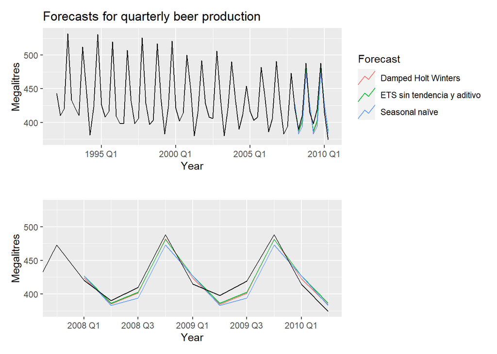

```r
# Entrenamiento de los modelos
beer_fit <- beer_train %>%
  model(
    `Seasonal naïve` = SNAIVE(Beer),
    `Damped Holt Winters` = ETS(Beer ~ error("M") + trend("Ad") +
                           season("M")),
    `ETS sin tendencia y aditivo` = ETS(Beer ~ error("A") + trend("N") + season("A"))
  )

# Pronóstico
beer_fc <- beer_fit %>%
  forecast(h = 10)

gg_beer <- beer_fc %>%
  autoplot(filter(aus_production, year(Quarter) >= 1992), level = NULL) +
  xlab("Year") + ylab("Megalitres") +
  ggtitle("Forecasts for quarterly beer production") +
  guides(colour=guide_legend(title="Forecast"))

gg_beer_zoom <-  gg_beer + tidyquant::coord_x_date(xlim = c("2007-10-01","2010-04-01")) + ggtitle("") +
  theme(legend.position = "none")
(gg_beer) / (gg_beer_zoom)
```

```r
# Los errores de pronóstico
accuracy(beer_fc, recent_production)
```

```
# A tibble: 3 × 10
  .model                   .type    ME  RMSE   MAE   MPE  MAPE  MASE RMSSE  ACF1
  <chr>                    <chr> <dbl> <dbl> <dbl> <dbl> <dbl> <dbl> <dbl> <dbl>
1 Damped Holt Winters      Test  2.57   9.68  8.80 0.568  2.12 0.616 0.577 0.220
2 ETS sin tendencia y adi… Test  0.857 10.3   9.64 0.143  2.32 0.674 0.616 0.175
3 Seasonal naïve           Test  5.2   14.3  13.4  1.15   3.17 0.937 0.853 0.132
```

El mejor fue Holt-Winters

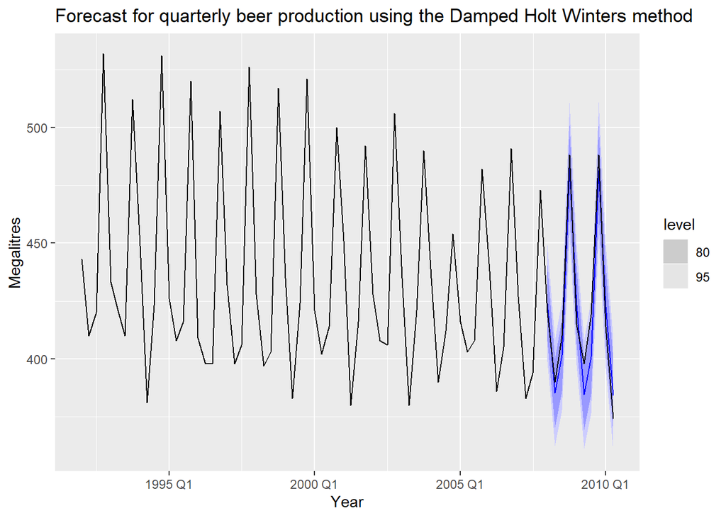

```r
beer_fc %>%
  filter(.model == "Damped Holt Winters") %>%
  autoplot(filter(aus_production, year(Quarter) >= 1992)) +
  xlab("Year") + ylab("Megalitres") +
  ggtitle("Forecast for quarterly beer production using the Damped Holt Winters method") +
  guides(colour=guide_legend(title="Forecast"))
```

Otro ejemplo (empleo en el sector minorista de USA):

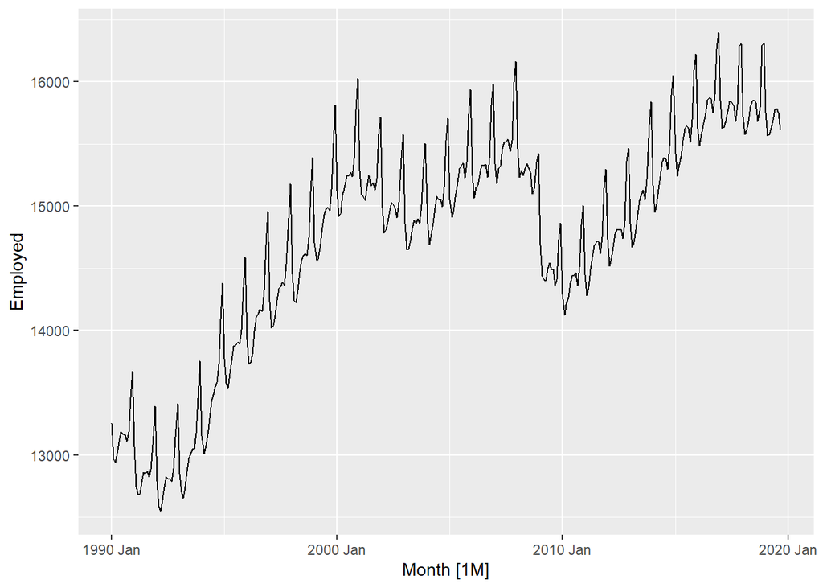

```r
us_retail_employment <- us_employment %>%
  filter(year(Month) >= 1990, Title == "Retail Trade")

us_retail_employment %>%
  autoplot(Employed)
```

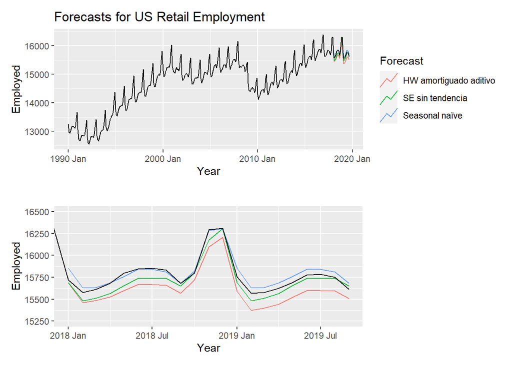

```r
us_retail_train <- us_retail_employment %>%
  filter(year(Month) <=2017)

us_retail_fit <- us_retail_train %>%
  model(
    `Seasonal naïve` = SNAIVE(Employed),
    `SE sin tendencia` = ETS(Employed ~ error("A") + trend("N") + season("A")),
    `HW amortiguado aditivo` = ETS(Employed ~ error("A") + trend("Ad") + season("A"))
  )

# Pronóstico
us_retail_fc <- us_retail_fit %>%
  forecast(h = 21)

gg_usret <- us_retail_fc %>%
  autoplot(us_retail_employment, level = NULL) +
  xlab("Year") + ylab("Employed") +
  ggtitle("Forecasts for US Retail Employment") +
  guides(colour=guide_legend(title="Forecast"))

gg_usret_zoom <-  gg_usret + tidyquant::coord_x_date(xlim = c("2018-01-01","2019-09-01"), ylim = c(15250, 16500)) + ggtitle("") +
  theme(legend.position = "none")

(gg_usret) / (gg_usret_zoom)
```

```r
# Los errores de pronóstico
accuracy(us_retail_fc, us_retail_employment)
```

```
# A tibble: 3 × 11
  .model          Serie…¹ .type    ME  RMSE   MAE    MPE  MAPE  MASE RMSSE  ACF1
  <chr>           <chr>   <chr> <dbl> <dbl> <dbl>  <dbl> <dbl> <dbl> <dbl> <dbl>
1 HW amortiguado… CEU420… Test  151.  157.  151.   0.956 0.956 0.628 0.544 0.215
2 SE sin tendenc… CEU420… Test   62.5  77.8  66.5  0.396 0.422 0.277 0.270 0.340
3 Seasonal naïve  CEU420… Test  -35.8  56.1  44.2 -0.229 0.281 0.184 0.194 0.520
# … with abbreviated variable name ¹Series_ID
```

Snaive es mejor.

## Modelo de descomposición STL

Implementando modelos de descomposición STL para mdoelar la serie en dos componentes:

- Para el componente estacional
- Para la serie desestacionalizada, con suavización exponencial simple.

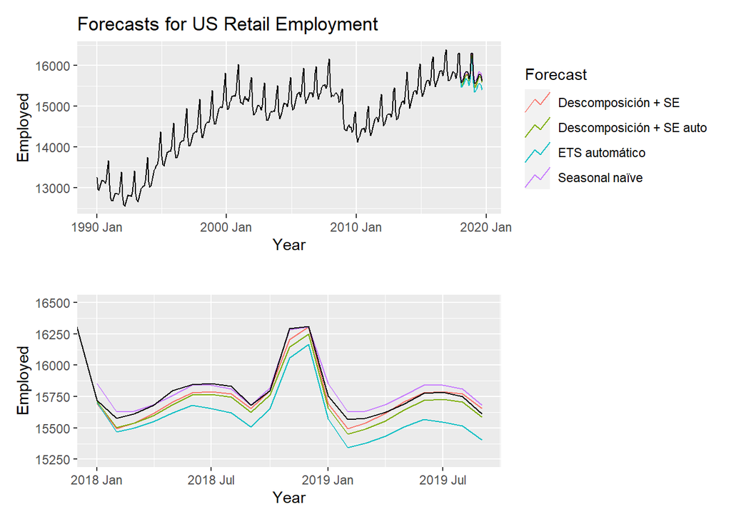

```r
us_retail_fit <- us_retail_train %>%
  model(
    `Seasonal naïve` = SNAIVE(Employed),
    `ETS automático` = ETS(Employed),
    `Descomposición + SE` = decomposition_model(
      STL(Employed ~ trend(), robust = TRUE),
    ETS(season_adjust ~ error("A") + trend("N") + season("N"))
    ),
    `Descomposición + SE auto` = decomposition_model(
      STL(Employed ~ trend(), robust = TRUE),
    ETS(season_adjust)
    )
  )

# Pronóstico
us_retail_fc <- us_retail_fit %>%
  forecast(h = 21)

gg_usret <- us_retail_fc %>%
  autoplot(us_retail_employment, level = NULL) +
  xlab("Year") + ylab("Employed") +
  ggtitle("Forecasts for US Retail Employment") +
  guides(colour=guide_legend(title="Forecast"))

gg_usret_zoom <-  gg_usret + tidyquant::coord_x_date(xlim = c("2018-01-01","2019-09-01"), ylim = c(15250, 16500)) + ggtitle("") +
  theme(legend.position = "none")

(gg_usret) / (gg_usret_zoom)
```

```r
# Los errores de pronóstico
accuracy(us_retail_fc, us_retail_employment) %>% arrange(MAPE)
```

```
# A tibble: 4 × 11
  .model         Serie…¹ .type    ME  RMSE   MAE    MPE  MAPE  MASE RMSSE   ACF1
  <chr>          <chr>   <chr> <dbl> <dbl> <dbl>  <dbl> <dbl> <dbl> <dbl>  <dbl>
1 Descomposició… CEU420… Test   34.6  52.7  43.5  0.219 0.276 0.181 0.183 0.477
2 Seasonal naïve CEU420… Test  -35.8  56.1  44.2 -0.229 0.281 0.184 0.194 0.520
3 Descomposició… CEU420… Test   71.1  77.8  71.1  0.450 0.450 0.296 0.270 0.0716
4 ETS automático CEU420… Test  175.  182.  175.   1.11  1.11  0.728 0.632 0.429
# … with abbreviated variable name ¹Series_ID
```

Como podemos ver fue una mejor opción.

## Combinación de modelos

Podemos hacer la combinación de dos o más modelos:

```r
us_retail_fit2 <- us_retail_fit %>%
  mutate(
    modelo_combinado = (`Seasonal naïve` + `Descomposición + SE`)/2
    ) %>%
  select(-c(`ETS automático`, `Descomposición + SE auto`))

accuracy(us_retail_fit2)
```

```
# A tibble: 3 × 11
  Series_ID     .model    .type    ME  RMSE   MAE    MPE  MAPE  MASE RMSSE  ACF1
  <chr>         <chr>     <chr> <dbl> <dbl> <dbl>  <dbl> <dbl> <dbl> <dbl> <dbl>
1 CEU4200000001 Seasonal… Trai… 98.5  288.  240.  0.661  1.65  1     1     0.984
2 CEU4200000001 Descompo… Trai…  8.50  40.5  29.7 0.0590 0.204 0.124 0.140 0.315
3 CEU4200000001 modelo_c… Trai… 53.5  156.  130.  0.360  0.893 0.542 0.542 0.966
```

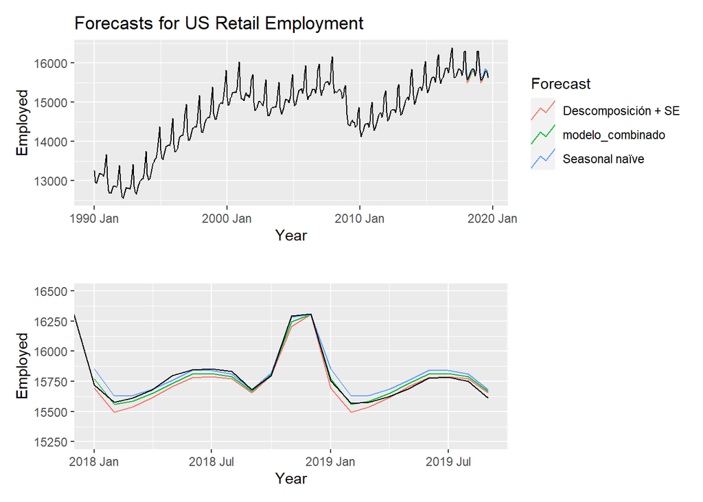

```r
# Pronóstico
us_retail_fc2 <- us_retail_fit2 %>%
  forecast(h = 21)

gg_usret <- us_retail_fc2 %>%
  autoplot(us_retail_employment, level = NULL) +
  xlab("Year") + ylab("Employed") +
  ggtitle("Forecasts for US Retail Employment") +
  guides(colour=guide_legend(title="Forecast"))

gg_usret_zoom <-  gg_usret + tidyquant::coord_x_date(xlim = c("2018-01-01","2019-09-01"), ylim = c(15250, 16500)) + ggtitle("") +
  theme(legend.position = "none")

(gg_usret) / (gg_usret_zoom)
```

```r
# Los errores de pronóstico
accuracy(us_retail_fc2, us_retail_employment)
```

```
# A tibble: 3 × 11
  .model      Serie…¹ .type      ME  RMSE   MAE      MPE  MAPE  MASE RMSSE  ACF1
  <chr>       <chr>   <chr>   <dbl> <dbl> <dbl>    <dbl> <dbl> <dbl> <dbl> <dbl>
1 Descomposi… CEU420… Test   34.6    52.7  43.5  0.219   0.276 0.181 0.183 0.477
2 Seasonal n… CEU420… Test  -35.8    56.1  44.2 -0.229   0.281 0.184 0.194 0.520
3 modelo_com… CEU420… Test   -0.623  35.1  30.8 -0.00479 0.195 0.128 0.122 0.562
# … with abbreviated variable name ¹Series_ID
```

Otro ejemplo:

Sin patrón estacional marcado (comparando con drift):

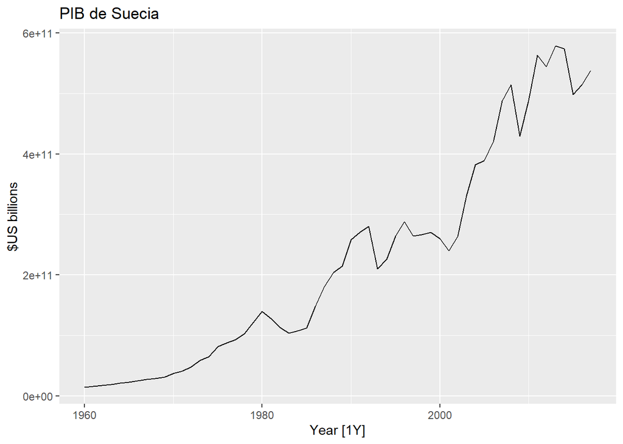

```r
suecia <- global_economy %>%
  filter(Country == "Sweden")

suecia %>%
  autoplot(GDP) +
    ggtitle("PIB de Suecia") + ylab("$US billions")
```

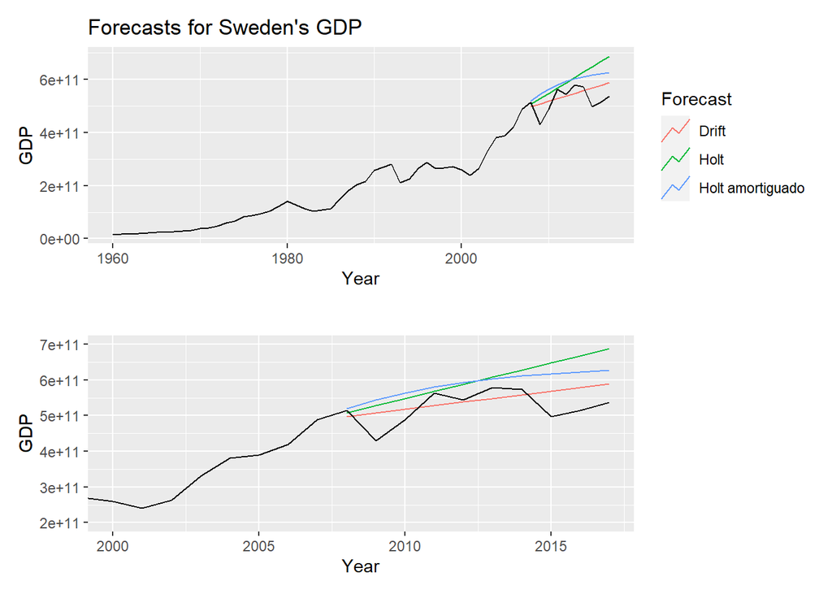

```r
suecia_train <- suecia %>%
  filter(Year <=2007)

suecia_fit <- suecia_train %>%
  model(
    `Drift` = RW(GDP ~ drift()),
    `Holt` = ETS(GDP ~ error("A") + trend("A") + season("N")),
    `Holt amortiguado` = ETS(GDP ~ error("A") + trend("Ad") + season("N"))
  )

# Pronóstico
suecia_fc <- suecia_fit %>%
  forecast(h = 10)

gg_suecia <- suecia_fc %>%
  autoplot(suecia, level = NULL) +
  xlab("Year") + ylab("GDP") +
  ggtitle("Forecasts for Sweden's GDP") +
  guides(colour=guide_legend(title="Forecast"))

gg_suecia_zoom <-  gg_suecia + coord_cartesian(xlim = c(2000,2017), ylim = c(2e+11,7e+11)) +
  ggtitle("") + theme(legend.position = "none")

(gg_suecia) / (gg_suecia_zoom)
```

```r
# Los errores de pronóstico
accuracy(suecia_fc, suecia) %>% select(MAPE, everything()) %>% arrange(MAPE)
```

```
# A tibble: 3 × 11
   MAPE .model  Country .type       ME    RMSE     MAE    MPE  MASE RMSSE   ACF1
  <dbl> <chr>   <fct>   <chr>    <dbl>   <dbl>   <dbl>  <dbl> <dbl> <dbl>  <dbl>
1  7.86 Drift   Sweden  Test  -1.90e10 4.61e10 3.96e10  -4.18  2.34  1.87 0.237
2 12.7  Holt a… Sweden  Test  -6.39e10 7.58e10 6.39e10 -12.7   3.77  3.07 0.0937
3 14.7  Holt    Sweden  Test  -7.36e10 9.34e10 7.48e10 -14.5   4.42  3.79 0.409
```

Es mejor Drift en este caso.